# Pitcher card

# Lucas Erceg

RHP · KC

2026 · 52 G (0 GS) · 901 pitches · Mar 28 – Sep 27, 2026

Independent portfolio sample by Devin Jenkinson, not affiliated with any club. Every number is computed from public Statcast data.

Three big takeaways

1Attack

The slider is the put-away pitch. Use it to finish at-bats.

41% of two-strike pitches · 27% whiffs/swing (59 swings)

It grades 95 Stuff+. No other pitch has 50+ two-strike swings yet.

2Avoid

Limit the changeup. It is his most damaging pitch.

xRV/100 -0.67 shrunk (raw -2.01) · .430 xwOBAcon · 122 pitches

When behind in the count he throws it 12% of the time; the sinker grades +0.88 there instead.

3Watch

27% chased on 116 out-of-zone pitches

Fastball height splits are too thin to call (78 swings up, 15 down).

Charts

### Movement

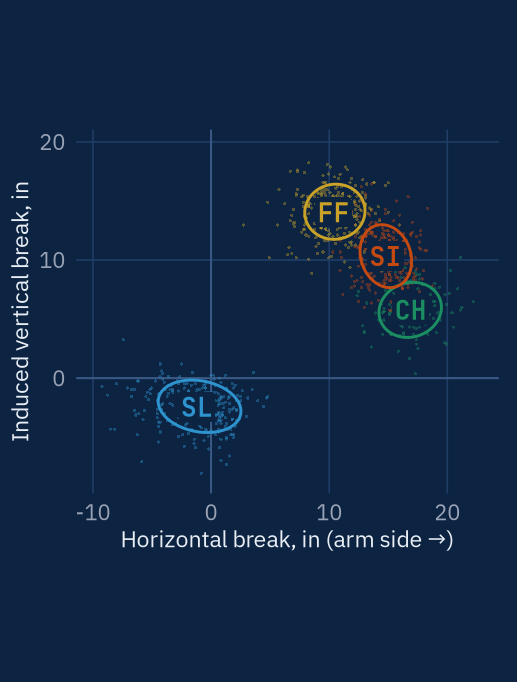

n = 884 pitches. Ellipses hold about 68% of each type; codes sit at the averages.

### Location by count

He throws 60% of pitches in the zone when behind and 45% when ahead.

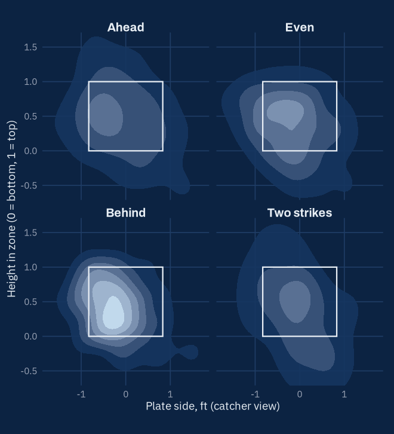

n = 884. Ahead 98 · even 307 · behind 188 · two strikes 291 pitches. Box = rule-book zone.

### Put-away

The SL is 41% of two-strike pitches vs 28% overall.

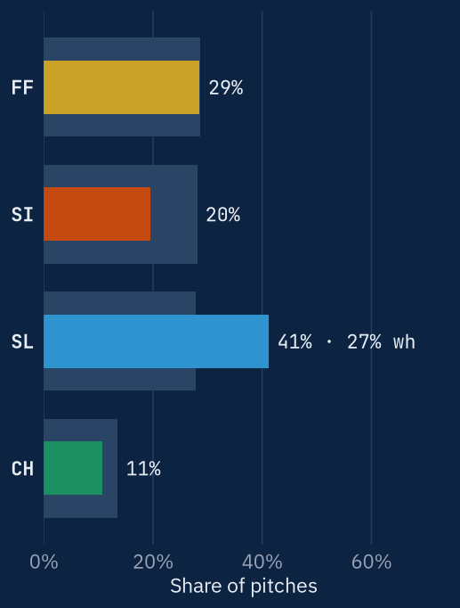

Two-strike n: SL 120, FF 83, SI 57, CH 31. Grey bars = overall usage; wh = whiffs per swing (shown with 50+ swings).

### Arsenal

[output not shown]

IVB / HB in inches (HB + = arm side). VAA in degrees at the front of the plate. xRV/100 = expected run value per 100 pitches, pitcher’s view, shrunk with a 250-pitch prior. Stuff+ = this project’s shape-only model (100 = MLB average, 10 = 1 SD).

### Vs. batter hand

| Pitch | LHH # | Use | Whiff | xwOBAcon | RHH # | Use | Whiff | xwOBAcon |
| --- | --- | --- | --- | --- | --- | --- | --- | --- |
| FF | 159 | 34% | 22% | .394 | 99 | 24% | – | .307 |
| SI | 91 | 20% | – | .309 | 162 | 39% | 14% | .354 |
| SL | 101 | 22% | – | .231 | 150 | 36% | 28% | .243 |
| CH | 115 | 25% | 22% | .484 | 7 | 2% | – | .383 |

Use = share of pitches to that side. Whiff = whiffs per swing, shown with 50+ swings.